# Conjuntos Difusos

En contraste con un conjunto clásico, un conjunto difuso, como su nombre lo indica, es un conjunto sin un límite nítido. Es decir, la transición de "pertenecer a un conjunto" a "no pertenecer a un conjunto" es gradual, y esta transición suave se caracteriza por funciones de pertenencia que dan a los conjuntos difusos flexibilidad en la modelación de expresiones lingüísticas comúnmente utilizadas como "el agua está caliente" o "la temperatura es alta." Como señaló Zadeh en 1965 en su artículo seminal titulado "Conjuntos Difusos," estos conjuntos o clases definidos de manera imprecisa "juegan un papel importante en el pensamiento humano, particularmente en los dominios de reconocimiento de patrones, comunicación de información y abstracción." Cabe destacar que la difusividad no proviene del azar de los miembros constituyentes de los conjuntos, sino de la naturaleza incierta e imprecisa de los pensamientos y conceptos abstractos.

# Funciones de membresía

Una de las piezas fundamentales en la teoría de conjuntos difusos es la función de membresía. Esta función, generalmente denotada como 𝜇𝐴(𝑥), mide el grado de pertenencia de un elemento 𝑥 al conjunto difuso 𝐴. A diferencia de los conjuntos clásicos, donde la función de pertenencia sólo toma los valores 0 o 1, la función de membresía en un conjunto difuso puede tomar cualquier valor real en el intervalo [0, 1]. Un valor de 0 indica que el elemento no pertenece al conjunto, un valor de 1 indica plena pertenencia, y cualquier valor intermedio indica un grado parcial de pertenencia.

Existen diferentes tipos de funciones de membresía que se utilizan para modelar diferentes situaciones. A continuación se mostrarán los algoritmos que representan algunas de las más comunes en el lenguaje de programación Python:

***Si se desea ejecutar alguno de los siguientes algoritmos mostrados, debe ejecutarse el comando 'pip install matplotlib' para descargar la biblioteca de matplotlib, herramienta necesaria para visualizar las gráficas correspondientes de cada función.**

## Función para evaluar una función de membresía triangular izquierda

$$ \text{MF\_triangularIzquierda}(x; a, b) = \begin{cases} 1, & \text{si } x \leq a. \\ \frac{b - x}{b - a}, & \text{si } a \leq x \leq b. \\ 0, & \text{si } b \leq x. \end{cases} $$

- **x** = Punto de evaluación.
- **a** = Vértice izquierdo de la función triangular.
- **b** = Vértice derecho de la función triangular.
- **min_universo** = Valor mínimo del conjunto universo.
- **max_universo** = Valor máximo del conjunto universo.rso.

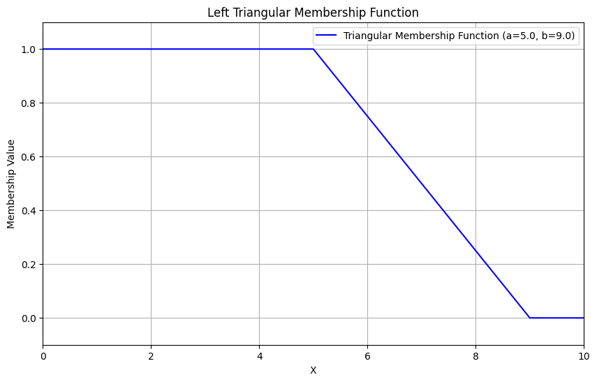

```python
import matplotlib.pyplot as plt
import numpy as np

def MF_triangularIzquierda(X, a, b):
    if X <= a:
        return 1
    elif a < X < b:
        return -(1 / (b - a)) * (X - a) + 1
    else:
        return 0

# Función para solicitar los valores de a, b y el rango del conjunto universo:
def ltMF_main():
    while True:
        a = float(input("Ingrese el valor de a: "))
        b = float(input("Ingrese el valor de b: "))
        if a < b:
            break
        else:
            print("Error: El valor de a debe ser menor que b. Por favor, ingrese los valores nuevamente.")

    while True:
        min_universo = float(input("Ingrese el valor mínimo del conjunto universo: "))
        max_universo = float(input("Ingrese el valor máximo del conjunto universo: "))
        if min_universo < max_universo:
            break
        else:
            print("Error: El valor mínimo del conjunto universo debe ser menor al valor máximo. Por favor, ingrese los valores nuevamente.")

    plot_MF_triangularIzquierda(a, b, min_universo, max_universo)

# Función para graficar la MF:
def plot_MF_triangularIzquierda(a, b, min_universo, max_universo):
    X_values = np.linspace(min_universo, max_universo, 500)
    X_values = np.concatenate(([a, b], X_values))
    X_values = np.sort(X_values)

    MF_values = [MF_triangularIzquierda(X, a, b) for X in X_values]

    plt.figure(figsize=(10, 6))
    plt.plot(X_values, MF_values, label=f'Triangular Membership Function (a={a}, b={b})', color='blue')

    plt.xlabel('X')
    plt.ylabel('Membership Value')
    plt.title('Left Triangular Membership Function')
    plt.legend()
    plt.grid(True)
    plt.ylim(-0.1, 1.1)
    plt.xlim(min_universo, max_universo)
    plt.show()

ltMF_main()
```

## Función para evaluar una función de membresía triangular derecha

$$ \text{MF\_triangularDerecha}(x; a, b) = \begin{cases} 0, & \text{si } x \leq a. \\ \frac{x - a}{b - a}, & \text{si } a \leq x \leq b. \\ 1, & \text{si } b \leq x. \end{cases} $$

- **x** = Punto de evaluación.
- **a** = Vértice izquierdo de la función triangular.
- **b** = Vértice derecho de la función triangular.
- **min_universo** = Valor mínimo del conjunto universo.
- **max_universo** = Valor máximo del conjunto universo.

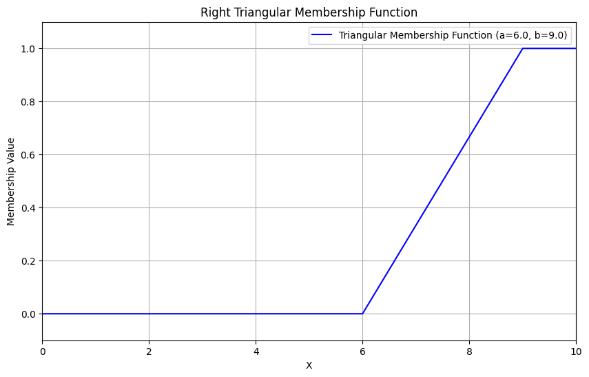

```python
import matplotlib.pyplot as plt
import numpy as np

def MF_triangularDerecha(X, a, b):
    if X <= a:
        return 0
    elif a < X < b:
        return (1 / (b - a)) * (X - a)
    else:
        return 1

# Función para solicitar los valores de a, b y el rango del conjunto universo:
def rtMF_main():
    while True:
        a = float(input("Ingrese el valor de a: "))
        b = float(input("Ingrese el valor de b: "))
        if a < b:
            break
        else:
            print("Error: El valor de a debe ser menor que b. Por favor, ingrese los valores nuevamente.")

    while True:
        min_universo = float(input("Ingrese el valor mínimo del conjunto universo: "))
        max_universo = float(input("Ingrese el valor máximo del conjunto universo: "))
        if min_universo < max_universo:
            break
        else:
            print("Error: El valor mínimo del conjunto universo debe ser menor al valor máximo. Por favor, ingrese los valores nuevamente.")

    plot_MF_triangularDerecha(a, b, min_universo, max_universo)

# Función para graficar la MF:
def plot_MF_triangularDerecha(a, b, min_universo, max_universo):
    X_values = np.linspace(min_universo, max_universo, 500)
    X_values = np.concatenate(([a, b], X_values))
    X_values = np.sort(X_values)

    MF_values = [MF_triangularDerecha(X, a, b) for X in X_values]

    plt.figure(figsize=(10, 6))
    plt.plot(X_values, MF_values, label=f'Triangular Membership Function (a={a}, b={b})', color='blue')

    plt.xlabel('X')
    plt.ylabel('Membership Value')
    plt.title('Right Triangular Membership Function')
    plt.legend()
    plt.grid(True)
    plt.ylim(-0.1, 1.1)
    plt.xlim(min_universo, max_universo)
    plt.show()

rtMF_main()
```

## Función para evaluar una función de membresía triangular

$$ \text{MF\_triangular}(x; a, b, c) = \begin{cases} 0, & \text{si } x \leq a. \\ \frac{x - a}{b - a}, & \text{si } a \leq x \leq b. \\ \frac{c - x}{c - b}, & \text{si } b \leq x \leq c. \\ 0, & \text{si } c \leq x. \end{cases} $$

- **x** = Punto de evaluación.
- **a** = Vértice izquierdo de la función triangular.
- **b** = Vértice central de la función triangular.
- **c** = Vértice derecho de la función triangular.
- **min_universo** = Valor mínimo del conjunto universo.
- **max_universo** = Valor máximo del conjunto universo.

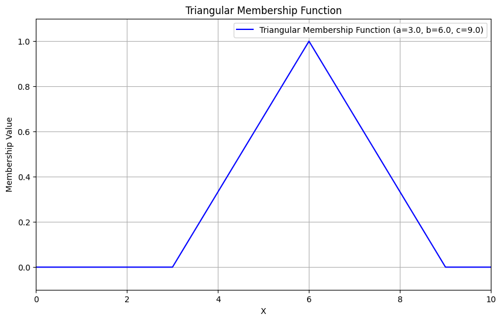

```python
import matplotlib.pyplot as plt
import numpy as np

# Función para evaluar una MF triangular:
def MF_triangular(X, a, b, c):
    if X <= a:
        return 0
    elif a < X <= b:
        return (1 / (b - a)) * (X - a)
    elif b < X < c:
        return -(1 / (c - b)) * (X - c)
    else:
        return 0

# Función para solicitar los valores de a, b, c y el rango del conjunto universo:
def tnMF_main():
    while True:
        a = float(input("Ingrese el valor de a: "))
        b = float(input("Ingrese el valor de b: "))
        c = float(input("Ingrese el valor de c: "))
        if a < b < c:
            break
        else:
            print("Error: El valor de a debe ser menor que b y el valor de b debe ser menor que c. Por favor, ingrese los valores nuevamente.")

    while True:
        min_universo = float(input("Ingrese el valor mínimo del conjunto universo: "))
        max_universo = float(input("Ingrese el valor máximo del conjunto universo: "))
        if min_universo < max_universo:
            break
        else:
            print("Error: El valor mínimo del conjunto universo debe ser menor al valor máximo. Por favor, ingrese los valores nuevamente.")

    plot_MF_triangular(a, b, c, min_universo, max_universo)

# Función para graficar la MF:
def plot_MF_triangular(a, b, c, min_universo, max_universo):
    X_values = np.linspace(min_universo, max_universo, 500)
    X_values = np.concatenate(([a, b, c], X_values))
    X_values = np.sort(X_values)

    MF_values = [MF_triangular(X, a, b, c) for X in X_values]

    plt.figure(figsize=(10, 6))
    plt.plot(X_values, MF_values, label=f'Triangular Membership Function (a={a}, b={b}, c={c})', color='blue')

    plt.xlabel('X')
    plt.ylabel('Membership Value')
    plt.title('Triangular Membership Function')
    plt.legend()
    plt.grid(True)
    plt.ylim(-0.1, 1.1)
    plt.xlim(min_universo, max_universo)
    plt.show()

tnMF_main()
```

## Función para evaluar una función de membresía trapezoidal

$$ \text{MF\_trapezoidal}(x; a, b, c, d) = \begin{cases} 0, & \text{si } x \leq a. \\ \frac{x - a}{b - a}, & \text{si } a \leq x \leq b. \\ 1, & \text{si } b \leq x \leq c. \\ \frac{d - x}{d - c}, & \text{si } c \leq x \leq d. \\ 0, & \text{si } d \leq x. \end{cases} $$

- **x** = Punto de evaluación.
- **a** = Vértice inferior izquierdo de la función trapezoidal.
- **b** = Vértice superior izquierdo de la función trapezoidal.
- **c** = Vértice superior derecho de la función trapezoidal.
- **d** = Vértice inferior derecho de la función trapezoidal.
- **min_universo** = Valor mínimo del conjunto universo.
- **max_universo** = Valor máximo del conjunto universo.

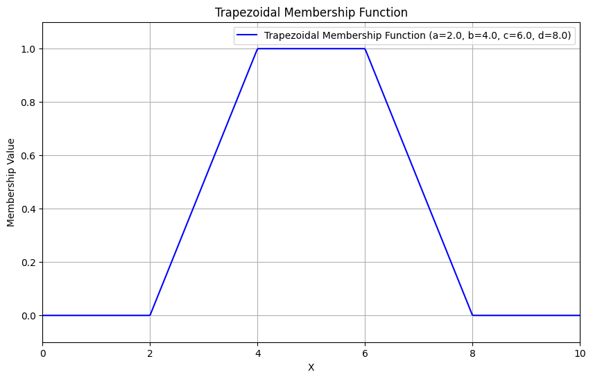

```python
import matplotlib.pyplot as plt
import numpy as np

def MF_trapezoidal(X, a, b, c, d):
    if X <= a:
        return 0
    elif a < X <= b:
        return (X - a) / (b - a)
    elif b < X <= c:
        return 1
    elif c < X < d:
        return (d - X) / (d - c)
    else:
        return 0

# Función para solicitar los valores de a, b, c, d y el rango del conjunto universo:
def tpMF_main():
    while True:
        a = float(input("Ingrese el valor de a: "))
        b = float(input("Ingrese el valor de b: "))
        c = float(input("Ingrese el valor de c: "))
        d = float(input("Ingrese el valor de d: "))
        if a < b < c < d:
            break
        else:
            print("Error: Los valores deben cumplir con la condición a < b < c < d. Por favor, ingrese los valores nuevamente.")

    while True:
        min_universo = float(input("Ingrese el valor mínimo del conjunto universo: "))
        max_universo = float(input("Ingrese el valor máximo del conjunto universo: "))
        if min_universo < max_universo:
            break
        else:
            print("Error: El valor mínimo del conjunto universo debe ser menor al valor máximo. Por favor, ingrese los valores nuevamente.")

    plot_MF_trapezoidal(a, b, c, d, min_universo, max_universo)

# Función para graficar la MF:
def plot_MF_trapezoidal(a, b, c, d, min_universo, max_universo):
    X_values = np.linspace(min_universo, max_universo, 500)
    MF_values = [MF_trapezoidal(X, a, b, c, d) for X in X_values]

    plt.figure(figsize=(10, 6))
    plt.plot(X_values, MF_values, label=f'Trapezoidal Membership Function (a={a}, b={b}, c={c}, d={d})', color='blue')

    plt.xlabel('X')
    plt.ylabel('Membership Value')
    plt.title('Trapezoidal Membership Function')
    plt.legend()
    plt.grid(True)
    plt.ylim(-0.1, 1.1)
    plt.xlim(min_universo, max_universo)
    plt.show()

tpMF_main()
```

## Función para evaluar una función de membresía gaussiana izquierda

$$ \text{MF\_gaussianaIzquierda}(x; \sigma, c) = \begin{cases} 1, & \text{si } x \leq c. \\ e^{-\frac{1}{2}\left(\frac{x - c}{\sigma}\right)^2}, & \text{si } c \leq x. \end{cases} $$

- **x** = Punto de evaluación.
- **c** = Punto central de la función de membresía gaussiana.
- **$\sigma$** = Dispersión de la función de membresía gaussiana.
- **min_universo** = Valor mínimo del conjunto universo.
- **max_universo** = Valor máximo del conjunto universo.

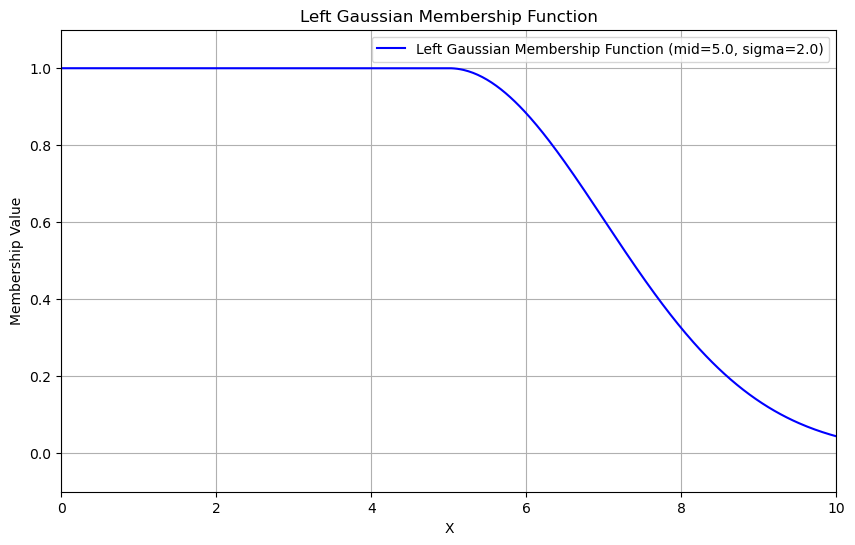

```python
import matplotlib.pyplot as plt
import numpy as np

def MF_gaussianaIzquierda(X, mid, sigma):
    if X <= mid:
        return 1
    else:
        return np.exp(-0.5 * ((X - mid) / sigma) ** 2)

# Función para solicitar los valores de mid, sigma y el rango del conjunto universo:
def lgMF_main():
    mid = float(input("Ingrese el valor del centro: "))
    while True:
        sigma = float(input("Ingrese el valor de la desviación estándar (sigma): "))
        if sigma > 0:
            break
        else:
            print("Error: El valor de sigma debe ser mayor a cero. Por favor, ingrese el valor nuevamente.")

    while True:
        min_universo = float(input("Ingrese el valor mínimo del conjunto universo: "))
        max_universo = float(input("Ingrese el valor máximo del conjunto universo: "))
        if min_universo < max_universo:
            break
        else:
            print("Error: El valor mínimo del conjunto universo debe ser menor al valor máximo. Por favor, ingrese los valores nuevamente.")

    plot_MF_gaussianaIzquierda(mid, sigma, min_universo, max_universo)

# Función para graficar la MF:
def plot_MF_gaussianaIzquierda(mid, sigma, min_universo, max_universo):
    X_values = np.linspace(min_universo, max_universo, 500)
    X_values = np.concatenate(([mid], X_values))
    X_values = np.sort(X_values)

    MF_values = [MF_gaussianaIzquierda(X, mid, sigma) for X in X_values]

    plt.figure(figsize=(10, 6))
    plt.plot(X_values, MF_values, label=f'Left Gaussian Membership Function (mid={mid}, sigma={sigma})', color='blue')

    plt.xlabel('X')
    plt.ylabel('Membership Value')
    plt.title('Left Gaussian Membership Function')
    plt.legend()
    plt.grid(True)
    plt.ylim(-0.1, 1.1)
    plt.xlim(min_universo, max_universo)
    plt.show()

lgMF_main()
```

## Función para evaluar una función de membresía gaussiana derecha

$$ \text{MF\_gaussianaDerecha}(x; \sigma, c) = \begin{cases} e^{-\frac{1}{2}\left(\frac{x - c}{\sigma}\right)^2}, & \text{si } x \leq c. \\ 1, & \text{si } c \leq x. \end{cases} $$

- **x** = Punto de evaluación.
- **c** = Punto central de la función de membresía gaussiana.
- **$\sigma$** = Dispersión de la función de membresía gaussiana.
- **min_universo** = Valor mínimo del conjunto universo.
- **max_universo** = Valor máximo del conjunto universo.

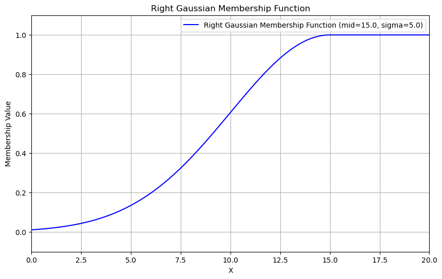

```python
import matplotlib.pyplot as plt
import numpy as np

def MF_gaussianaDerecha(X, mid, sigma):
    if X > mid:
        return 1
    else:
        return np.exp(-0.5 * ((X - mid) / sigma) ** 2)

# Función para solicitar los valores de mid, sigma y el rango del conjunto universo:
def rgMF_main():
    mid = float(input("Ingrese el valor del centro: "))

    while True:
        sigma = float(input("Ingrese el valor de la desviación estándar (sigma): "))
        if sigma > 0:
            break
        else:
            print("Error: El valor de sigma debe ser mayor a cero. Por favor, ingrese el valor nuevamente.")

    while True:
        min_universo = float(input("Ingrese el valor mínimo del conjunto universo: "))
        max_universo = float(input("Ingrese el valor máximo del conjunto universo: "))
        if min_universo < max_universo:
            break
        else:
            print("Error: El valor mínimo del conjunto universo debe ser menor al valor máximo. Por favor, ingrese los valores nuevamente.")

    plot_MF_gaussianaDerecha(mid, sigma, min_universo, max_universo)

# Función para graficar la MF:
def plot_MF_gaussianaDerecha(mid, sigma, min_universo, max_universo):
    X_values = np.linspace(min_universo, max_universo, 500)
    X_values = np.concatenate(([mid], X_values))
    X_values = np.sort(X_values)

    MF_values = [MF_gaussianaDerecha(X, mid, sigma) for X in X_values]

    plt.figure(figsize=(10, 6))
    plt.plot(X_values, MF_values, label=f'Right Gaussian Membership Function (mid={mid}, sigma={sigma})', color='blue')

    plt.xlabel('X')
    plt.ylabel('Membership Value')
    plt.title('Right Gaussian Membership Function')
    plt.legend()
    plt.grid(True)
    plt.ylim(-0.1, 1.1)
    plt.xlim(min_universo, max_universo)
    plt.show()

rgMF_main()
```

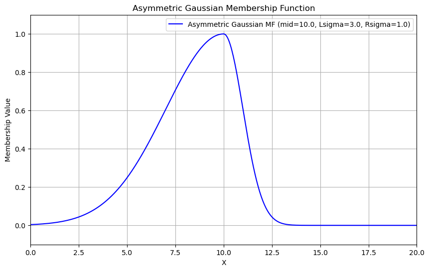

```python
import matplotlib.pyplot as plt
import numpy as np

def MF_gaussianaAsimetrica(X, mid, Lsigma, Rsigma):
    if X <= mid:
        return np.exp(-0.5 * ((X - mid) / Lsigma) ** 2)
    else:
        return np.exp(-0.5 * ((X - mid) / Rsigma) ** 2)

# Función para solicitar los valores de mid, Lsigma, Rsigma y el rango del conjunto universo:
def agMF_main():
    mid = float(input("Ingrese el valor del centro: "))

    while True:
        Lsigma = float(input("Ingrese el valor de la desviación estándar izquierda (Lsigma): "))
        if Lsigma > 0:
            break
        else:
            print("Error: El valor de sigma debe ser mayor a cero. Por favor, ingrese el valor nuevamente.")

    while True:
        Rsigma = float(input("Ingrese el valor de la desviación estándar derecha (Rsigma): "))
        if Rsigma > 0:
            break
        else:
            print("Error: El valor de sigma debe ser mayor a cero. Por favor, ingrese el valor nuevamente.")

    while True:
        min_universo = float(input("Ingrese el valor mínimo del conjunto universo: "))
        max_universo = float(input("Ingrese el valor máximo del conjunto universo: "))
        if min_universo < max_universo:
            break
        else:
            print("Error: El valor mínimo del conjunto universo debe ser menor al valor máximo. Por favor, ingrese los valores nuevamente.")

    plot_MF_gaussianaAsimetrica(mid, Lsigma, Rsigma, min_universo, max_universo)

# Función para graficar la MF:
def plot_MF_gaussianaAsimetrica(mid, Lsigma, Rsigma, min_universo, max_universo):
    X_values = np.linspace(min_universo, max_universo, 500)
    MF_values = [MF_gaussianaAsimetrica(X, mid, Lsigma, Rsigma) for X in X_values]

    plt.figure(figsize=(10, 6))
    plt.plot(X_values, MF_values, label=f'Asymmetric Gaussian MF (mid={mid}, Lsigma={Lsigma}, Rsigma={Rsigma})', color='blue')

    plt.xlabel('X')
    plt.ylabel('Membership Value')
    plt.title('Asymmetric Gaussian Membership Function')
    plt.legend()
    plt.grid(True)
    plt.ylim(-0.1, 1.1)
    plt.xlim(min_universo, max_universo)
    plt.show()

agMF_main()
```

## Función para evaluar una función de membresía de escalón unitario

- **x** = Punto de evaluación.
- **a** = Punto de flanco de subida.
- **min_universo** = Valor mínimo del conjunto universo.
- **max_universo** = Valor máximo del conjunto universo.

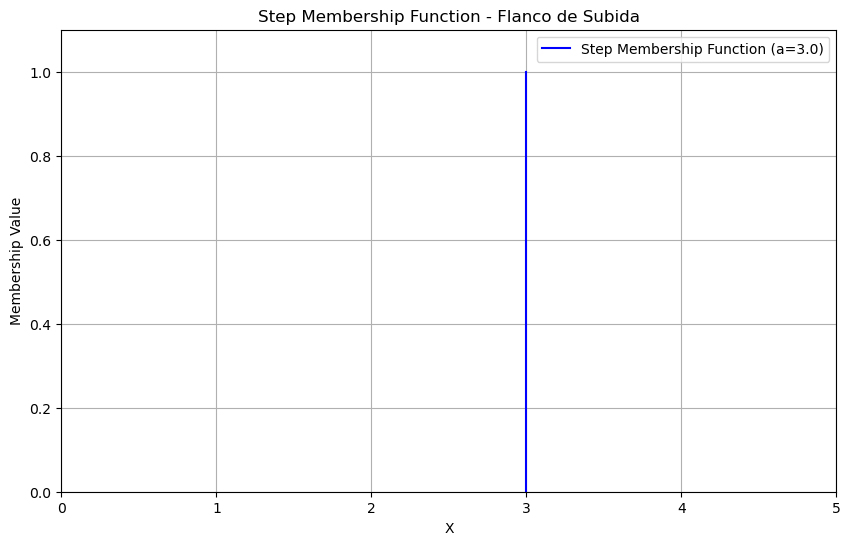

```python
import matplotlib.pyplot as plt
import numpy as np

def MF_escalonUnitario(X, a):
    return 1 if X >= a else 0

# Función para solicitar el valor de a y el rango del conjunto universo:
def stMF_main():
    a = float(input("Ingrese el valor de a: "))

    while True:
        min_universo = float(input("Ingrese el valor mínimo del conjunto universo: "))
        max_universo = float(input("Ingrese el valor máximo del conjunto universo: "))
        if min_universo < max_universo:
            break
        else:
            print("Error: El valor mínimo del conjunto universo debe ser menor al valor máximo. Por favor, ingrese los valores nuevamente.")

    plot_MF_escalonUnitario(a, min_universo, max_universo)

# Función para graficar la MF:
def plot_MF_escalonUnitario(a, min_universo, max_universo):
    X_values = np.linspace(a - 0.000000001, a + 0.000000001, 200)
    MF_values = [MF_escalonUnitario(X, a) for X in X_values]

    plt.figure(figsize=(10, 6))
    plt.plot(X_values, MF_values, label=f'Step Membership Function (a={a})', color='blue')

    plt.xlabel('X')
    plt.ylabel('Membership Value')
    plt.title('Step Membership Function - Flanco de Subida')
    plt.legend()
    plt.grid(True)
    plt.ylim(0, 1.1)
    plt.xlim(min_universo, max_universo)
    plt.show()

stMF_main()
```

## Función para evaluar una función de membresía de Cauchy

$$ \text{MF\_Cauchy}(x; a, b, c) = \frac{1}{1 + \left|\frac{x - c}{a}\right|^{2b}} $$

- **x** = Punto de evaluación.
- **a** = Valor del ancho de la función.
- **b** = Valor del parámetro de forma.
- **c** = Valor de la cambana generalizada.
- **min_universo** = Valor mínimo del conjunto universo.
- **max_universo** = Valor máximo del conjunto universo.erso.

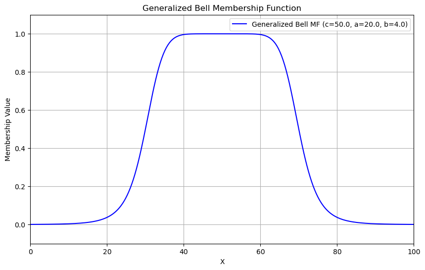

```python
import matplotlib.pyplot as plt
import numpy as np

def MF_generalizedBell(X, c, a, b):
    return 1 / (1 + abs((X - c) / a) ** (2 * b))

# Función para solicitar los valores de c, a, b y el rango del conjunto universo:
def gbMF_main():
    c = float(input("Ingrese el valor del centro: "))
    a = float(input("Ingrese el valor del ancho (a): "))
    b = float(input("Ingrese el valor del parámetro de forma (b): "))

    while True:
        min_universo = float(input("Ingrese el valor mínimo del conjunto universo: "))
        max_universo = float(input("Ingrese el valor máximo del conjunto universo: "))
        if min_universo < max_universo:
            break
        else:
            print("Error: El valor mínimo del conjunto universo debe ser menor al valor máximo. Por favor, ingrese los valores nuevamente.")

    plot_MF_generalizedBell(c, a, b, min_universo, max_universo)

# Función para graficar la MF:
def plot_MF_generalizedBell(c, a, b, min_universo, max_universo):
    X_values = np.linspace(min_universo, max_universo, 500)
    MF_values = [MF_generalizedBell(X, c, a, b) for X in X_values]

    plt.figure(figsize=(10, 6))
    plt.plot(X_values, MF_values, label=f'Generalized Bell MF (c={c}, a={a}, b={b})', color='blue')

    plt.xlabel('X')
    plt.ylabel('Membership Value')
    plt.title('Generalized Bell Membership Function')
    plt.legend()
    plt.grid(True)
    plt.ylim(-0.1, 1.1)
    plt.xlim(min_universo, max_universo)
    plt.show()

gbMF_main()
```

## Función para evaluar una función de membresía sigmoidea

$$ \text{sig}(x; a, c) = \frac{1}{1 + \exp [-a(x - c)]} $$

- **x** = Punto de evaluación.
- **a** = Valor de la pendiente.
- **c** = Valor del punto de inflexión.
- **min_universo** = Valor mínimo del conjunto universo.
- **max_universo** = Valor máximo del conjunto universo.

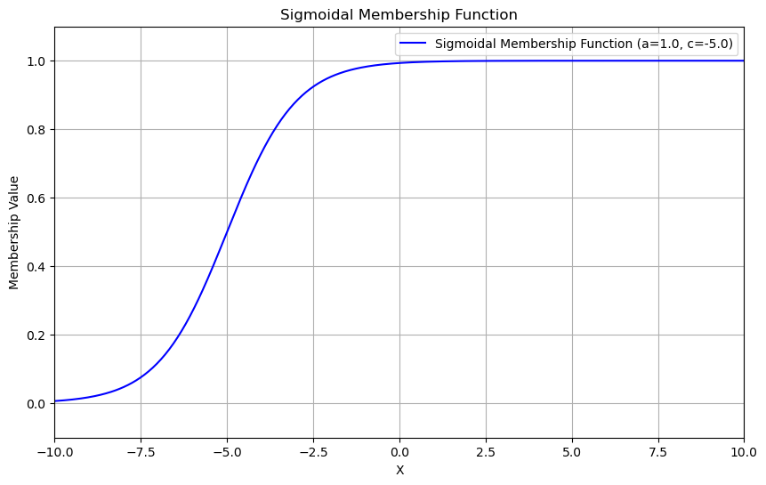

```python
import matplotlib.pyplot as plt
import numpy as np

def MF_sigmoidal(X, a, c):
    return 1 / (1 + np.exp(-a * (X - c)))

# Función para solicitar los valores de a, c y el rango del conjunto universo:
def sigMF_main():
    a = float(input("Ingrese el valor de la pendiente (a): "))
    c = float(input("Ingrese el valor del punto de inflexión (c): "))

    while True:
        min_universo = float(input("Ingrese el valor mínimo del conjunto universo: "))
        max_universo = float(input("Ingrese el valor máximo del conjunto universo: "))
        if min_universo < max_universo:
            break
        else:
            print("Error: El valor mínimo del conjunto universo debe ser menor al valor máximo. Por favor, ingrese los valores nuevamente.")

    plot_MF_sigmoidal(a, c, min_universo, max_universo)

# Función para graficar la MF:
def plot_MF_sigmoidal(a, c, min_universo, max_universo):
    X_values = np.linspace(min_universo, max_universo, 500)
    MF_values = [MF_sigmoidal(X, a, c) for X in X_values]

    plt.figure(figsize=(10, 6))
    plt.plot(X_values, MF_values, label=f'Sigmoidal Membership Function (a={a}, c={c})', color='blue')

    plt.xlabel('X')
    plt.ylabel('Membership Value')
    plt.title('Sigmoidal Membership Function')
    plt.legend()
    plt.grid(True)
    plt.ylim(-0.1, 1.1)
    plt.xlim(min_universo, max_universo)
    plt.show()

sigMF_main()
```

## Función para evaluar una función de membresía izquierda-derecha (L-R)

$$ \text{LR}(x; c, \alpha, \beta) = \begin{cases} F_L\left(\frac{c - x}{\alpha}\right), & x \leq c. \\ F_R\left(\frac{x - c}{\beta}\right), & x \geq c. \end{cases} $$

$$ \begin{aligned} F_L(x) &= \max(0, \sqrt{1 - x^2}). \\ F_R(x) &= e^{-|x|^3}. \end{aligned} $$

- **x** = Punto de evaluación.
- **$\alpha$** = Define la dispersión de la parte izquierda de la función.
- **$\beta$** = Define la dispersión de la parte derecha de la función.
- **c** = Valor del centro de la función.
- **min_universo** = Valor mínimo del conjunto universo.
- **max_universo** = Valor máximo del conjunto universo.erso.

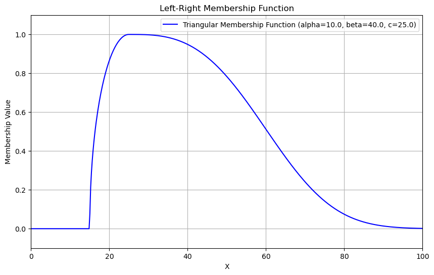

```python
import matplotlib.pyplot as plt
import numpy as np

def MF_leftRight(X, alpha, beta, c):
    if X >= c:
        x1 = (X - c) / beta
        return np.exp(-abs(x1**3))
    else:
        x2 = (c - X) / alpha
        return max(0, np.sqrt(1 - x2**2))

# Función para solicitar los valores de c, a, b y el rango del conjunto universo:
def lrMF_main():
    c = float(input("Ingrese el valor del centro (c): "))
    alpha = float(input("Ingrese el valor de alpha: "))
    beta = float(input("Ingrese el valor de beta: "))

    while True:
        min_universo = float(input("Ingrese el valor mínimo del conjunto universo: "))
        max_universo = float(input("Ingrese el valor máximo del conjunto universo: "))
        if min_universo < max_universo:
            break
        else:
            print("Error: El valor mínimo del conjunto universo debe ser menor al valor máximo. Por favor, ingrese los valores nuevamente.")

    plot_MF_leftRight(alpha, beta, c, min_universo, max_universo)

# Función para graficar la MF:
def plot_MF_leftRight(alpha, beta, c, min_universo, max_universo):
    X_values = np.linspace(min_universo, max_universo, 500)
    MF_values = [MF_leftRight(X, alpha, beta, c) for X in X_values]

    plt.figure(figsize=(10, 6))
    plt.plot(X_values, MF_values, label=f'Triangular Membership Function (alpha={alpha}, beta={beta}, c={c})', color='blue')

    plt.xlabel('X')
    plt.ylabel('Membership Value')
    plt.title('Left-Right Membership Function')
    plt.legend()
    plt.grid(True)
    plt.ylim(-0.1, 1.1)
    plt.xlim(min_universo, max_universo)
    plt.show()

lrMF_main()
```